# An overview of pQTLdata

Department of Public Health and Primary Care

University of Cambridge

Cambridge, UK

https://jinghuazhao.github.io/

2024-06-04

This package intends to gather information on meta-data and relevant scripts in proteogenomic analysis.

# 1 Collections

As used in several years of proteomic analysis and for future extensions, the collections are in two locations:

1. **`data/`**. R datasets.
2. **`inst/`**. `EndNote/`, `Olink/`, `scripts/`, `pQTLdata.sh`, `docs.sh` which spread into the package’s root directory after installation.

While `library(help=pQTLdata)` displays the general information, `? pQTLdata` can give a list of data objects in the package.

# 2 Protein panels

The Olink qPCR inflammation panel (`inf1`) used in the SCALLOP consortium seeds the collection.

Table 2.1: Olink/inflammation panel

| gene | prot | uniprot | target | target.short | chr | start | end | ensembl_gene_id | alt_name | ensGene | chromosome | start38 | end38 |
| --- | --- | --- | --- | --- | --- | --- | --- | --- | --- | --- | --- | --- | --- |
| ADA | ADA | P00813 | Adenosine Deaminase (ADA) | ADA | 20 | 43248163 | 43280874 | ENSG00000196839 | NA | NA | NA | NA | NA |
| ARTN | ARTN | Q5T4W7 | Artemin (ARTN) | ARTN | 1 | 44398992 | 44402913 | ENSG00000117407 | NA | NA | NA | NA | NA |
| AXIN1 | AXIN1 | O15169 | Axin-1 (AXIN1) | AXIN1 | 16 | 337440 | 402673 | ENSG00000103126 | NA | NA | NA | NA | NA |
| BDNF | BDNF | P23560 | Brain-derived neutrophic factor (BDNF) | BDNF | 11 | 27676440 | 27743605 | ENSG00000176697 | NA | NA | NA | NA | NA |
| CASP8 | CASP.8 | Q14790 | Caspase 8 (CASP-8) | CASP-8 | 2 | 202098166 | 202152434 | ENSG00000064012 | NA | NA | NA | NA | NA |
| CCL11 | CCL11 | P51671 | Eotaxin-1 (CCL11) | CCL11 | 17 | 32612687 | 32615353 | ENSG00000172156 | CCL11 | NA | NA | NA | NA |
| CCL13 | MCP.4 | Q99616 | Monocyte chemotactic protein 4 (MCP-4) | MCP-4 | 17 | 32683471 | 32685629 | ENSG00000181374 | CCL13 | NA | NA | NA | NA |
| CCL19 | CCL19 | Q99731 | C-C motif chemokine 19 (CCL19) | CCL19 | 9 | 34689564 | 34691274 | ENSG00000172724 | NA | NA | NA | NA | NA |
| CCL2 | MCP.1 | P13500 | Monocyte chemotactic protein 1 (MCP-1) | MCP-1 | 17 | 32582304 | 32584222 | ENSG00000108691 | CCL2 | NA | NA | NA | NA |
| CCL20 | CCL20 | P78556 | C-C motif chemokine 20 (CCL20) | CCL20 | 2 | 228678558 | 228682272 | ENSG00000115009 | NA | NA | NA | NA | NA |
| CCL23 | CCL23 | P55773 | C-C motif chemokine 23 (CCL23) | CCL23 | 17 | 34340096 | 34345005 | ENSG00000167236 | NA | ENSG00000274736 | 17 | 36013056 | 36017972 |
| CCL25 | CCL25 | O15444 | C-C motif chemokine 25 (CCL25) | CCL25 | 19 | 8117651 | 8127534 | ENSG00000131142 | NA | ENSG00000131142 | 19 | 8052318 | 8062660 |
| CCL28 | CCL28 | Q9NRJ3 | C-C motif chemokine 28 (CCL28) | CCL28 | 5 | 43376747 | 43412493 | ENSG00000151882 | NA | NA | NA | NA | NA |
| CCL3 | MIP.1.alpha | P10147 | Macrophage inflammatory protein 1-alpha (MIP-1 alpha) | MIP-1 alpha | 17 | 34415602 | 34417515 | ENSG00000006075 | NA | ENSG00000277632 | 17 | 36088256 | 36090169 |
| CCL4 | CCL4 | P13236 | C-C motif chemokine 4 (CCL4) | CCL4 | 17 | 34430983 | 34433014 | ENSG00000129277 | NA | ENSG00000275302 | 17 | 36103827 | 36105621 |
| CCL7 | MCP.3 | P80098 | Monocyte chemotactic protein 3 (MCP-3) | MCP-3 | 17 | 32597240 | 32599261 | ENSG00000108688 | CCL7 | NA | NA | NA | NA |
| CCL8 | MCP.2 | P80075 | Monocyte chemotactic protein 2 (MCP-2) | MCP-2 | 17 | 32646055 | 32648421 | ENSG00000108700 | CCL8 | NA | NA | NA | NA |
| CD244 | CD244 | Q9BZW8 | Natural killer cell receptor 2B4 (CD244) | CD244 | 1 | 160799950 | 160832692 | ENSG00000122223 | NA | NA | NA | NA | NA |
| CD274 | PD.L1 | Q9NZQ7 | Programmed cell death 1 ligand 1 (PD-L1) | PD-L1 | 9 | 5450503 | 5470566 | ENSG00000120217 | NA | NA | NA | NA | NA |
| CD40 | CD40 | P25942 | CD40L receptor (CD40) | CD40 | 20 | 44746911 | 44758502 | ENSG00000101017 | NA | NA | NA | NA | NA |
| CD5 | CD5 | P06127 | T-cell surface glycoprotein CD5 (CD5) | CD5 | 11 | 60869867 | 60895324 | ENSG00000110448 | NA | NA | NA | NA | NA |
| CD6 | CD6 | P30203 | T-cell surface glycoprotein CD6 isoform (CD6) | CD6 | 11 | 60739115 | 60787849 | ENSG00000138675 | NA | ENSG00000013725 | 11 | 60971680 | 61020377 |
| CDCP1 | CDCP1 | Q9H5V8 | CUB domain-containing protein 1 (CDCP1) | CDCP1 | 3 | 45123770 | 45187914 | ENSG00000163814 | NA | NA | NA | NA | NA |
| CSF1 | CSF.1 | P09603 | Macrophage colony-stimulating factor 1 (CSF-1) | CSF-1 | 1 | 110452864 | 110473614 | ENSG00000184371 | NA | NA | NA | NA | NA |
| CST5 | CST5 | P28325 | Cystatin D (CST5) | CST5 | 20 | 23856572 | 23860387 | ENSG00000170367 | NA | NA | NA | NA | NA |
| CX3CL1 | CX3CL1 | P78423 | Fractalkine (CX3CL1) | CX3CL1 | 16 | 57406370 | 57418960 | ENSG00000006210 | NA | NA | NA | NA | NA |
| CXCL1 | CXCL1 | P09341 | C-X-C motif chemokine 1 (CXCL1) | CXCL1 | 4 | 74735110 | 74736959 | ENSG00000163739 | NA | NA | NA | NA | NA |
| CXCL10 | CXCL10 | P02778 | C-X-C motif chemokine 10 (CXCL10) | CXCL10 | 4 | 76942273 | 76944650 | ENSG00000169245 | NA | NA | NA | NA | NA |
| CXCL11 | CXCL11 | O14625 | C-X-C motif chemokine 11 (CXCL11) | CXCL11 | 4 | 76954835 | 76962568 | ENSG00000169248 | NA | NA | NA | NA | NA |
| CXCL5 | CXCL5 | P42830 | C-X-C motif chemokine 5 (CXCL5) | CXCL5 | 4 | 74861359 | 74864496 | ENSG00000163735 | NA | NA | NA | NA | NA |

[output cut: 62 more lines]

followed by inclusion of Olink_qPCR for all 12 panels, Olink NGS, Caprion and SWATH-MS panels. `SomaScanV4.1` is directly from SomaLogic.

It is of interest to compare some of these,

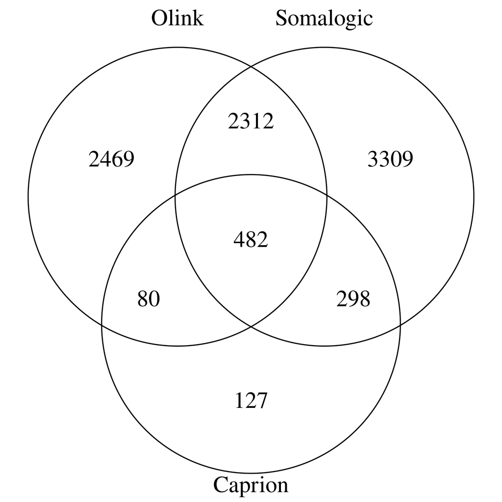

Figure 2.1: Overlap of Olink Explore HT, SomaLogic V4.1 and Caprion

and the latest SomaScan 11K

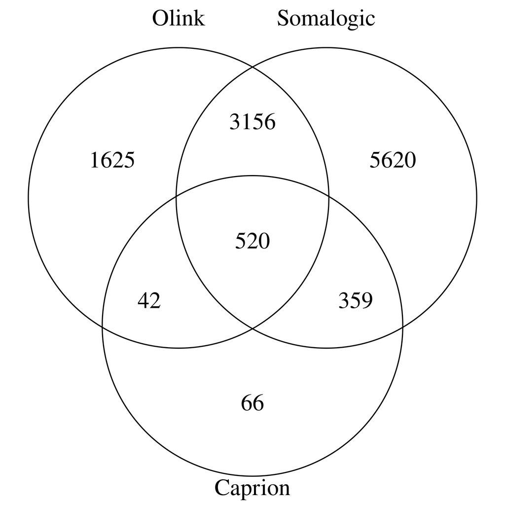

Figure 2.2: Overlap of Olink Explore HT, SomaLogic 11K and Caprion

# 3 Published data

This associates with the analysis of INTERVAL data as reported by Sun et al. (2018), which includes the panel `SomaLogic160410`, supplementary tables 4, 6, 18.

# 4 Reference data

Extractions `biomaRt`, `hg19` and `hg19Tables` are based on ENSEMBL BioMart and UCSC.

# 5 Scripts

An analysis involving COVID-19 data is in `Olink/` directory , while the `scripts/` directory records data generation which potentially can be extended.

Specifically, `pQTLdata.sh` handles package under Cambridge Service for Data Driven Discovery (CSD3) system, and `docs.sh` operates with GitHub.

# 6 URLs

- Cell Carta, https://cellcarta.com/
- EndNote, https://endnote.com/
- ENSEMBL BioMart, https://www.ensembl.org/index.html
- GitHub, https://github.com/
- INTERVAL study, http://www.donorhealth-btru.nihr.ac.uk/studies/interval-study/
- NULISA, https://alamarbio.com/technology/nulisa-platform/
- Olink, https://olink.com/ (https://olink.com/resources-support/publications-2/)
- SCALLOP consortium, http://www.scallop-consortium.com/
- Seer, https://seer.bio/
- SomaLogic, https://somalogic.com/
- SWATH-MS, https://www.creative-proteomics.com/ngpro/swath-ms.html
- UCSC, https://genome.ucsc.edu/

# References

The `EndNote/` directory includes references in Sun et al. (2018) and Suhre, McCarthy, and Schwenk (2020) formatted in EndNote.

Suhre, K., M. I. McCarthy, and J. M. Schwenk. 2020. “Genetics Meets Proteomics: Perspectives for Large Population-Based Studies.” Journal Article. *Nat Rev Genet*. https://doi.org/10.1038/s41576-020-0268-2.

Sun, B. B., J. C. Maranville, J. E. Peters, D. Stacey, J. R. Staley, J. Blackshaw, S. Burgess, et al. 2018. “Genomic Atlas of the Human Plasma Proteome.” Journal Article. *Nature* 558 (7708): 73–79. https://doi.org/10.1038/s41586-018-0175-2.